# ASESII 24A02 Project-Based Quiz 1

Ridge, Lasso, and Regularization for Neural Features

Le Dat Phuc An (24125052) Pham Nguyen Minh Quan (24125041) Tran Canh Anh Tuan (24125048) Vong Chi Van (24125049) **Group 06**:

2026-07-18

# Authorship and contribution statement

We confirm that every group member can explain the submitted analysis. AI use is reported in `Group06_AI_Log.csv`, and the group checked every AI-assisted item used in this report.

| Student | ID | Main contributions | Verification performed |
| --- | --- | --- | --- |
| Le Dat Phuc An | 24125052 | 1, 2A, 2B, 5A, and 5B | Verified 2D, 3B, and 4C by reproducing results and reviewing the report. |
| Pham Nguyen Minh Quan | 24125041 | 2D, 2E, 3A, 3B, and 4B | Verified 1, 2A, 5A, and 5B by checking methodology, code, and documentation. |
| Tran Canh Anh Tuan | 24125048 | 2A, 2B, 3C, 4A, 4C, 4E, 5A | Verified 2B, 2C, and 4B by reviewing implementation and numerical results. |
| Vong Chi Van | 24125049 | 2A, 2B, 2C, 4A, 4E | Verified Sections 2E, 3A, and 3C by checking derivations, code, and final outputs. |

# Abstract

This study investigates log prostate-specific antigen (`lpsa`) prediction in 97 prostatectomy patients using clinical covariates. To mitigate multicollinearity and prevent target leakage, we implement an immutable 80/20 train/test partition with training-only preprocessing. We compare Ordinary Least Squares (OLS) against regularized linear models (Ridge, Lasso, Elastic Net) and a non-linear Random ReLU feature representation ($M=200$). Mathematical derivations confirm that $L_2$ regularization stabilizes ill-conditioned Gram matrices by upwardly shifting eigenvalues, reducing the condition number by over 50% ($\kappa$ dropped from 16.97 to 7.49). Empirical five-fold cross-validation identifies Lasso (`lambda.min`) and Elastic Net as superior predictors over baseline OLS and static non-linear projections. For clinical deployment, we nominate the Elastic Net model on original predictors, which optimizes out-of-sample generalization while collaboratively shrinking correlated biomarkers. We emphasize that regularized coefficients represent conditional predictive slopes rather than causal biological mechanisms.

# Reproducible setup

```r
required_packages <- c("tidyverse", "glmnet", "broom", "knitr")
missing_packages <- required_packages[
  !vapply(required_packages, requireNamespace, logical(1), quietly = TRUE)
]
if (length(missing_packages)) {
  stop("Install the required packages before rendering: ",
    paste(missing_packages, collapse = ", "))
}

library(tidyverse)
library(glmnet)
library(broom)
library(knitr)

group_number <- as.integer(params$group_number)
if (length(group_number) != 1L || is.na(group_number) || group_number < 1L) {
  stop("Set params$group_number to your assigned positive group number.")
}

seeds <- list(
  split = 240200L + group_number,
  cv = 240300L + group_number,
  features = 240400L + group_number,
  perturbation = 240500L + group_number
)
```

## Shared helper functions

```r
find_exam_data <- function(filename) {
  input <- knitr::current_input(dir = TRUE)
  input_dir <- if (length(input) && nzchar(input)) dirname(input) else getwd()
  candidates <- c(
    file.path(input_dir, "data", filename),
    file.path(input_dir, "..", "data", filename),
    file.path(getwd(), "data", filename)
  )
  existing <- candidates[file.exists(candidates)]
  if (!length(existing)) stop("Cannot locate ", filename, " by a relative path.")
  hits <- unique(normalizePath(existing, winslash = "/", mustWork = TRUE))
  if (length(hits) > 1L && length(unique(unname(tools::md5sum(hits)))) > 1L) {
    stop("Multiple nonidentical copies of ", filename, " were found.")
  }
  hits[[1L]]
}

split_rows <- function(n, train_prop = 0.80, seed) {
  stopifnot(n >= 10L, train_prop > 0, train_prop < 1)
  set.seed(seed)
  train <- sort(sample.int(n, floor(train_prop * n), replace = FALSE))
  list(train = train, test = setdiff(seq_len(n), train))
}

fit_scaler <- function(x, tol = 1e-12) {
  x <- as.matrix(x)
  center <- colMeans(x)
  centered <- sweep(x, 2L, center, "-")
  scale <- sqrt(colMeans(centered^2))
  keep <- is.finite(scale) & scale > tol
  if (!any(keep)) stop("No nonconstant training predictor remains.")
  list(
    center = center[keep],
    scale = scale[keep],
    keep = keep,
    dropped = colnames(x)[!keep]
  )
}

apply_scaler <- function(x, prep) {
  x <- as.matrix(x)[, prep$keep, drop = FALSE]
  x <- sweep(x, 2L, prep$center, "-")
  sweep(x, 2L, prep$scale, "/")
}

make_foldid <- function(n, k = 5L, seed) {
  if (k < 3L || k > n) stop("Require 3 <= k <= number of training rows.")
  set.seed(seed)
  sample(rep(seq_len(k), length.out = n))
}

fit_cv_glmnet <- function(x, y, alpha, foldid) {
  glmnet::cv.glmnet(
    x = x,
    y = y,
    family = "gaussian",
    alpha = alpha,
    foldid = foldid,
    standardize = FALSE,
    intercept = TRUE,
    type.measure = "mse"
  )
}

score_regression <- function(y, prediction) {
  y <- as.numeric(y)
  prediction <- as.numeric(prediction)
  if (length(y) != length(prediction) || any(!is.finite(c(y, prediction)))) {
    stop("Metrics require equal-length finite vectors.")
  }
  c(
    RMSE = sqrt(mean((y - prediction)^2)),
    MAE = mean(abs(y - prediction))
  )
}

# counts variables (non-zero slopes) the model used (excluding intercept)
count_nonzero <- function(fit, s = "lambda.min", tol = 1e-8) {
  b <- as.matrix(stats::coef(fit, s = s))
  slopes <- b[rownames(b) != "(Intercept)", 1L]
  sum(abs(slopes) > tol, na.rm = TRUE)
}

# calculate L2 norm (excluding intercept)
get_l2_norm <- function(fit, s = "lambda.min") {
  b <- as.matrix(stats::coef(fit, s = s))
  slopes <- b[rownames(b) != "(Intercept)", 1L]
  sqrt(sum(slopes^2, na.rm = TRUE))
}

# calculate L1 norm (excluding intercept)
get_l1_norm <- function(fit, s = "lambda.min") {
  b <- as.matrix(stats::coef(fit, s = s))
  slopes <- b[rownames(b) != "(Intercept)", 1L]
  sum(abs(slopes), na.rm = TRUE)
}

# measure multicollinearity
safe_condition_numbers <- function(x, lambda, tol = 1e-10) {
  G <- crossprod(x) / nrow(x)
  eigenvalues <- eigen(G, symmetric = TRUE, only.values = TRUE)$values
  largest <- max(eigenvalues)
  smallest <- max(min(eigenvalues), 0)
  cutoff <- tol * max(1, largest)
  c(
    gram = if (smallest <= cutoff) Inf else largest / smallest,
    ridge = (largest + lambda) / (smallest + lambda)
  )
}

plot_model_result <- function(model, model_name) {
  model_result <- augment(model)
  ggplot(model_result, aes(x = .fitted, y = .resid)) +
    geom_point(color = "steelblue", size = 2, alpha = 0.8) +
    geom_hline(yintercept = 0, linetype = "dashed", color = "red", linewidth = 1) +
    theme_minimal() +
    labs(
      title = paste("Residual Plot Model:", model_name),
      subtitle = "Checking for non-linear patterns and constant variance",
      x = "Predicted lpsa (.fitted)",
      y = "Residuals (.resid)"
    )
}

vif_manual <- function(model) {
  X <- model.matrix(model)[, -1, drop = FALSE]
  sapply(seq_len(ncol(X)), function(i) {
    fit <- lm(X[, i] ~ X[, -i])
    1 / (1 - summary(fit)$r.squared)
  }) |> setNames(colnames(X))
}
```

# Problem 1. Prediction design and leakage control

## 1A. Target and predictors

```r
config <- if (group_number %% 2L == 1L) {
  list(
    file = "fat.csv",
    response = "brozek",
    excluded = c("brozek", "siri", "density", "free")
  )
} else {
  list(
    file = "prostate.csv",
    response = "lpsa",
    excluded = "lpsa"
  )
}

data_raw <- read.csv(find_exam_data(config$file), check.names = FALSE)
predictors <- setdiff(names(data_raw), config$excluded)
analysis_data <- data_raw[, c(config$response, predictors), drop = FALSE]

if (anyNA(analysis_data)) stop("Declare a training-only missing-value plan.")
if (!all(vapply(analysis_data, is.numeric, logical(1)))) {
  stop("The assigned response and predictors must be numeric.")
}
```

### 1. Response

The natural Logarithm of Prostate-Specific Antigen is measured by $lpsa$, which is a continuous number.

### 2. Candidate Predictors

| Candidate Predictors | Full Name | Type |
| --- | --- | --- |
| lcavol | Log Cancer Volume | Continuous |
| lweight | Log Prostate Weight | Continuous |
| age | Age | Continuous |
| lbph | Log Benign Prostatic Hyperplasia | Continuous |
| svi | Seminal Vesicle Invasion | Binary (0 / 1) |
| lcp | Log Capsular Penetration | Continuous |
| gleason | Gleason Score | Ordered Categorical |
| pgg45 | Percentage Gleason Grade 4/5 | Continuous (0–100) |

### 3. Unit of Observation

Each row of the dataset contains the information of a radical prostactomy treated patient which comprises of the target and the predictors values.

### 4. Study Population

The dataset contains 97 patients aged 41 to 79 with clinically localized adenocarcinoma who went through radical prostactomy at Stanford University Center by Dr. Thomas A. Stamey and his surgical team during the late 1980s.

### 5. Prediction Objective

To build a regression model that predicts the lpsa using the clinical variables (lcavol, lweight, age, lbph, svi, lcp, gleason, and pgg45).

### 6. Dataset Source

(Stamey et al. 1989) **[Paper](https://sci-hub.sg/storage/2024/6429/4cbb75646440af614abced23a70ba059/stamey1989.pdf)**

### 7. Required Exclusions

The response variable `lpsa`, was excluded from the predictor matrix because it is the outcome to be predicted. The remaining eight clinical variables were retained as predictors. Since the dataset contains no variables derived from `lpsa`, no additional exclusions were required. This prevents target leakage and ensures a fair comparison among the regression models. A predictor derived from `lpsa` would let the model exploit the test response during training, artificially inflating in-sample and out-of-sample metrics, making any model comparison meaningless.

## 1B. Split and train-only preprocessing

```r
split <- split_rows(nrow(analysis_data), seed = seeds$split)
train_id <- split$train
test_id <- split$test

x_raw <- as.matrix(analysis_data[, predictors, drop = FALSE])
y_raw <- analysis_data[[config$response]]

x_prep <- fit_scaler(x_raw[train_id, , drop = FALSE])
x_train <- apply_scaler(x_raw[train_id, , drop = FALSE], x_prep)
x_test <- apply_scaler(x_raw[test_id, , drop = FALSE], x_prep)
y_train <- y_raw[train_id]
y_test <- y_raw[test_id]

foldid <- make_foldid(nrow(x_train), k = 5L, seed = seeds$cv)
```

### 1. Split seed

- Seed `split` for 80/20 split: 240206
- Seed `cv` for k-fold split: 240306

**Leakage Safeguard:** Setting deterministic random seeds prior to partitioning ensures the split is reproducible and objective. This prevents regenerating splits until a favorable test set is achieved.

### 2. Train/Test Split

The dataset of 97 observations was partitioned into:

- **Training Set:** 77 observations
- **Test Set:** 20 observations

**Leakage Safeguard:** Isolating the test set at the very beginning acts as the primary barrier against information leakage. It ensures that the holdout data remains completely unseen during subsequent exploratory analysis, feature engineering, and model tuning phases.

### 3. Feature Scaling Rule

Continuous predictor variables were centered and scaled using the helper functions `fit_scaler()` and `apply_scaler()`. The scaling parameters were estimated **only from the training data** in `fit_scaler()` and then applied unchanged to both the training and test sets by `apply_scaler()`.

Specifically, each predictor was transformed as:
$$x_{\text{scaled}} = \frac{x -
\bar{x}_{\text{train}}}{\sqrt{\frac{1}{n_{\text{train}}}
\sum_{i=1}^{n_{\text{train}}} (x_i -
\bar{x}_{\text{train}})^2}}$$

where $\bar{x}_{\text{train}}$ is the mean of the predictor in the training set, and the denominator is the population standard deviation computed from the training observations.

**Leakage Safeguard:** Using the exact same scaling parameters (derived solely from the training data) to transform the test set prevents information leakage. If the entire dataset were scaled before splitting, the mean and variance of the holdout data would bleed into the training data.

### 4. Five-Fold Assignment Rule

A single, immutable five-fold cross-validation assignment vector (`foldid`) was generated on the 77 training observations using the designated `cv` random seed. To ensure fair and controlled comparisons, this exact same fold assignment was reused across all models evaluated:

- Ridge Regression
- Lasso Regression
- Elastic Net
- All subsequent hyperparameter grid evaluations

**Leakage Safeguard:** Generating the cross-validation folds strictly from the 77 training observations ensures the 20 test observations are excluded from the hyperparameter tuning process. Reusing the exact same `foldid` across all models ensures that model comparisons are fair and variance is minimized.

### 5. Missing-Value Plan

No missing values were detected. If any had been present, they would have been handled using a training-only imputation procedure before model fitting.

**Leakage Safeguard:** Calculating imputation statistics (like mean or median) strictly on the training set and then applying those exact values to fill `NA`s in the test set ensures that the statistical distribution of the holdout data does not influence the training data.

## 1C. Training-data exploration

The exploratory analysis in this section uses only the training observations to avoid information leakage from the holdout test set.

### Response distribution

```r
summary(y_train)
```

```
##    Min. 1st Qu.  Median    Mean 3rd Qu.    Max.
## -0.1625  1.7317  2.5915  2.5449  3.2753  5.5829
```

```r
sd(y_train)
```

```
## [1] 1.146853
```

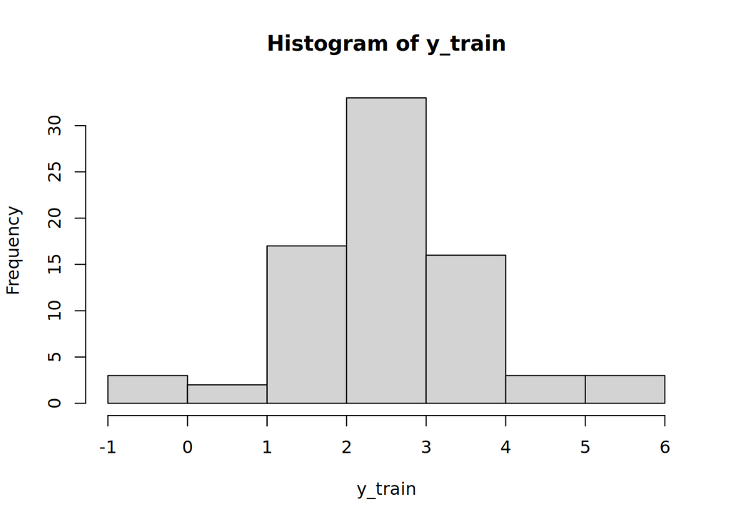

```r
hist(y_train, main = "Histogram of y_train", xlab = "y_train")
```

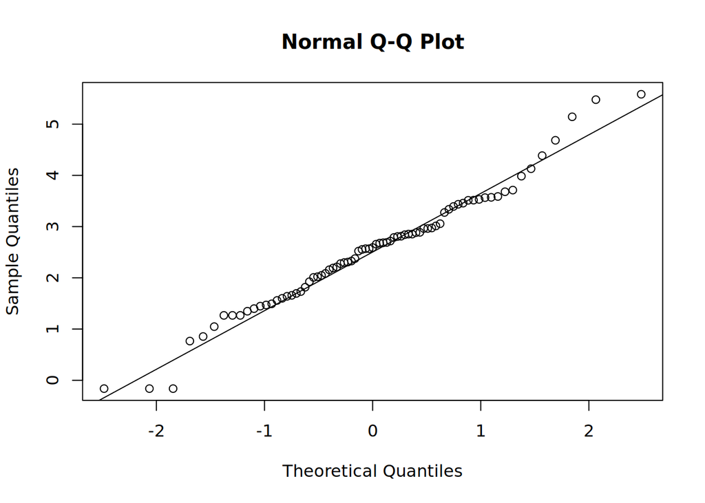

```r
qqnorm(y_train)
qqline(y_train)
```

The response variable (`lpsa`) has a mean of **2.55** and a median of **2.59**, indicating an approximately symmetric distribution. Most observations lie between **1.73** and **3.28**, with a standard deviation of **1.15**.

The histogram suggests that most observations are concentrated around the center, while only a few observations appear in the lower and upper tails. The normal Q–Q plot shows that most observations follow the reference line reasonably well, with slight departures in the tails. Overall, the response distribution is approximately normal, making it suitable for linear regression.

### Relationship exploration

#### Scatterplot matrix

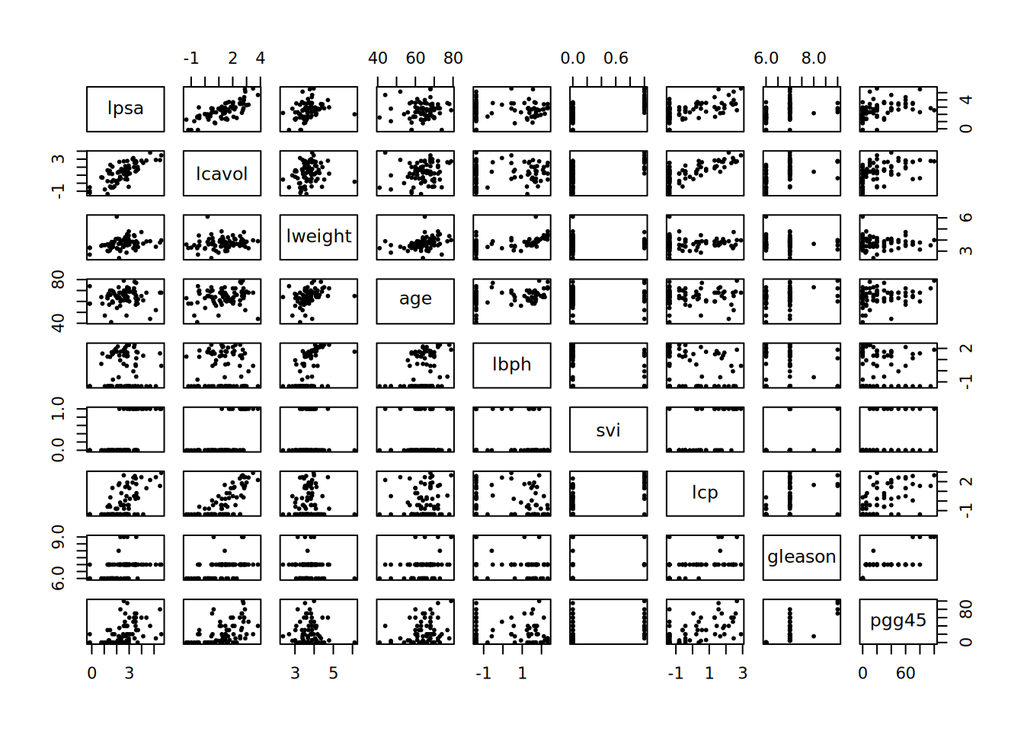

```r
pairs(analysis_data[train_id, ], pch = 20, cex = 0.6)
```

The scatterplot matrix provides a visual overview of pairwise relationships among the response and predictors. Several predictors exhibit approximately linear relationships with the response, particularly `lcavol`. Strong positive associations are also visible between several predictor pairs, suggesting that some variables may contain overlapping information.

#### Correlation matrix

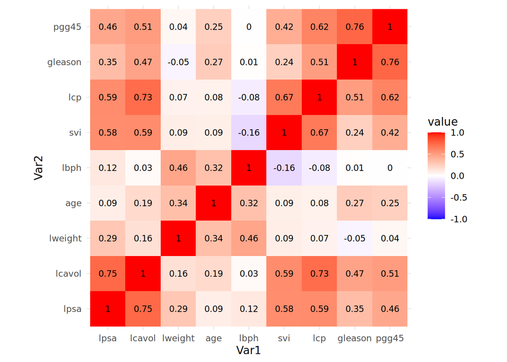

```r
cor_matrix <- cor(analysis_data[train_id, ])

heatmap_df <- expand.grid(
  Var1 = rownames(cor_matrix),
  Var2 = colnames(cor_matrix)
)

heatmap_df$value <- c(cor_matrix)

ggplot(heatmap_df, aes(Var1, Var2, fill = value)) +
  geom_tile() +
  geom_text(aes(label = round(value, 2)), size = 3) +
  scale_fill_gradient2(
    low = "blue",
    mid = "white",
    high = "red",
    midpoint = 0,
    limits = c(-1, 1)
  ) +
  coord_fixed() +
  theme_minimal()
```

The correlation heatmap shows that **lcavol** has the strongest linear relationship with the response (*r* = 0.75), indicating that tumor volume is the single most informative predictor of `lpsa`. Moderate positive correlations are also observed for **lcp** (*r* = 0.59) and **svi** (*r* = 0.58), whereas `age`, `lbph`, and `lweight` exhibit relatively weak marginal correlations with the response.

### Potential multicollinearity

The correlation matrix indicates several moderately to strongly correlated predictor pairs.

The strongest pairwise correlations include

- `gleason` and `pgg45` (**r = 0.76**),
- `lcavol` and `lcp` (**r = 0.73**),
- `lcp` and `svi` (**r = 0.67**),
- `lcavol` and `svi` (**r = 0.59**),
- `lcavol` and `gleason` (**r = 0.47**).

These relationships suggest that some predictors may contain overlapping information. However, pairwise correlation alone does not imply severe multicollinearity, since multicollinearity depends on the joint linear relationship among all predictors rather than individual pairs. Therefore, formal diagnostics such as the variance inflation factor (VIF) will be performed after fitting the OLS model to determine whether coefficient instability is present.

### One possible anomaly or influential observation

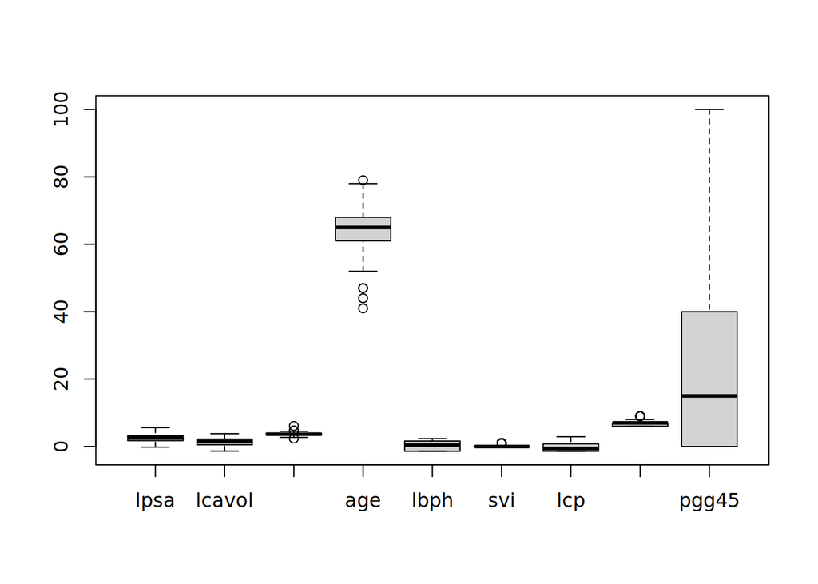

```r
boxplot(analysis_data[train_id, ])
```

### Question for regularized models

Based on the exploratory analysis, the following question will guide the remaining analysis

> Can regularization improve predictive performance and coefficient stability when predictors contain overlapping information?

# Problem 2. OLS, Ridge, and Lasso

## 2A. OLS baseline

The ordinary least squares (OLS) model was fitted using only the standardized training observations. The holdout test set remained untouched to ensure a fair comparison with regularized regression models.

### Fit OLS

```r
train_df <- as.data.frame(x_train)
train_df$lpsa <- y_train

ols_model <- lm(lpsa ~ ., data = train_df)
```

This serves as the baseline model for all subsequent comparisons with Ridge and Lasso regression.

### Coefficient estimates

```r
summary(ols_model)
```

```
##
## Call:
## lm(formula = lpsa ~ ., data = train_df)
##
## Residuals:
##     Min      1Q  Median      3Q     Max
## -1.7085 -0.3755  0.1074  0.3383  1.6307
##
## Coefficients:
##             Estimate Std. Error t value Pr(>|t|)
## (Intercept)  2.54492    0.08174  31.133  < 2e-16 ***
## lcavol       0.67399    0.12729   5.295 1.38e-06 ***
## lweight      0.20176    0.09821   2.054   0.0438 *
## age         -0.19423    0.09442  -2.057   0.0435 *
## lbph         0.13028    0.09764   1.334   0.1866
## svi          0.28165    0.11882   2.370   0.0206 *
## lcp         -0.09235    0.14712  -0.628   0.5323
## gleason     -0.01271    0.13395  -0.095   0.9247
## pgg45        0.16471    0.14078   1.170   0.2461
## ---
## Signif. codes:  0 '***' 0.001 '**' 0.01 '*' 0.05 '.' 0.1 ' ' 1
##
## Residual standard error: 0.7173 on 68 degrees of freedom
## Multiple R-squared:   0.65,  Adjusted R-squared:  0.6088
## F-statistic: 15.78 on 8 and 68 DF,  p-value: 7.049e-13
```

The fitted OLS model is statistically significant overall (**F = 15.78**, p < 0.001), indicating that at least one predictor contributes to explaining the variation in the response variable.

The model achieves a **Multiple** $R^2$ of 0.6500 and an **Adjusted** $R^2$ of 0.6088, suggesting that approximately **65%** of the variability in `lpsa` is explained by the eight clinical predictors.

Among the predictors,

- **lcavol** ($\beta=0.674$, p < 0.001),
- **lweight** ($\beta=0.202$, p = 0.0438),
- **age** ($\beta=-0.194$, p = 0.0435), and
- **svi** ($\beta=0.282$, p = 0.0206)

are statistically significant at the 5% significance level.

The remaining predictors (`lbph`, `lcp`, `gleason`, and `pgg45`) are not individually significant after adjusting for the other predictors in the model.

The estimated coefficient for **age** is negative ($\beta=-0.194$). This result suggests that the estimated effect of `age` changes after accounting for the remaining predictors in the model. The possibility of correlation among predictors is therefore investigated using VIF in the following subsection.

### Training error

```r
train_pred <- predict(ols_model)

train_mse <- mean((y_train - train_pred)^2)
train_rmse <- sqrt(train_mse)
cat("Training MSE :", round(train_mse, 4), "\n")
```

```
## Training MSE : 0.4544
```

```r
cat("Training RMSE:", round(train_rmse, 4), "\n")
```

```
## Training RMSE: 0.6741
```

The fitted OLS model achieved

- **Training MSE = 0.4544**
- **Training RMSE = 0.6741**

These quantities measure the goodness-of-fit on the training observations used to estimate the regression coefficients. Since the model is evaluated on the same data used for fitting, the training error is expected to underestimate the prediction error on unseen observations.

### Five-fold cross-validation

```r
cv_mse <- numeric(5)
for (i in 1:5) {
  train_fold <- train_df[foldid != i, ]
  valid_fold <- train_df[foldid == i, ]
  model <- lm(lpsa ~ ., data = train_fold)

  pred <- predict(model, newdata = valid_fold)
  cv_mse[i] <- mean((valid_fold$lpsa - pred)^2)
}
cv_table <- data.frame(
  Fold = 1:5,
  Validation_MSE = round(cv_mse, 4)
)

knitr::kable(cv_table)
```

| Fold | Validation_MSE |
| --- | --- |
| 1 | 0.8259 |
| 2 | 0.8568 |
| 3 | 0.4011 |
| 4 | 0.4893 |
| 5 | 0.9002 |

```r
cat("Mean CV MSE :", round(mean(cv_mse), 4), "\n")
```

```
## Mean CV MSE : 0.6947
```

```r
cat("Mean CV RMSE:", round(sqrt(mean(cv_mse)), 4), "\n")
```

```
## Mean CV RMSE: 0.8335
```

The validation errors obtained from the five folds are

| Fold | Validation MSE |
| --- | --- |
| 1 | 0.8259 |
| 2 | 0.8568 |
| 3 | 0.4011 |
| 4 | 0.4893 |
| 5 | 0.9002 |

The average cross-validation error is

- **Mean CV MSE = 0.6947**
- **Mean CV RMSE = 0.8335**

As expected, the cross-validation error is larger than the training error because each validation fold consists of observations that were not used to estimate the regression coefficients. Although some variation exists among the five folds, the validation errors remain within a similar range, suggesting that the predictive performance of the OLS model is reasonably stable across different training subsets.

### Residual diagnostics

#### Residual versus fitted values

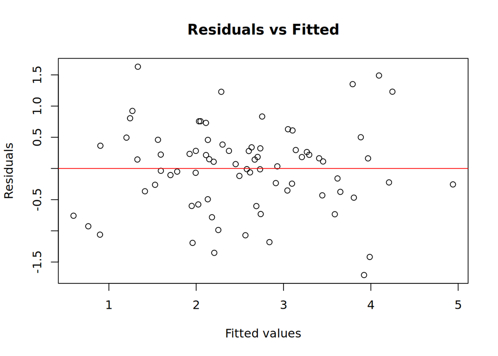

```r
plot(
  fitted(ols_model),
  resid(ols_model),
  xlab = "Fitted values",
  ylab = "Residuals",
  main = "Residuals vs Fitted"
)
abline(h = 0, col = "red")
```

The residual-versus-fitted plot shows that the residuals are randomly scattered around zero without noticeable curvature or funnel-shaped patterns. This suggests that the assumptions of

- linearity, and
- constant error variance (homoscedasticity)

are reasonably satisfied. No obvious pattern indicating model misspecification is observed.

#### Normal Q-Q plot

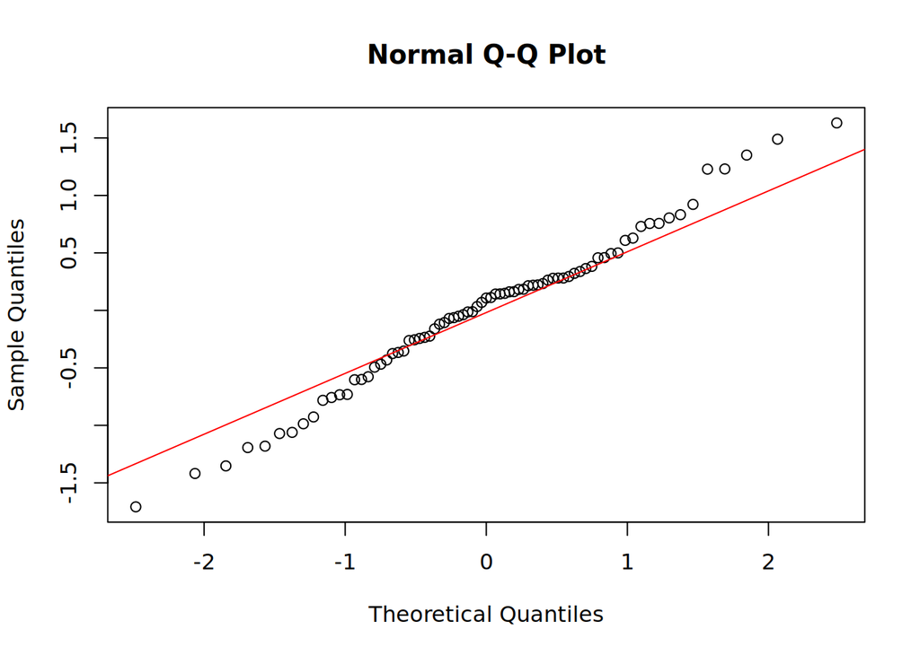

```r
qqnorm(resid(ols_model))
qqline(resid(ols_model), col = "red")
```

The normal Q–Q plot indicates that the residuals are approximately normally distributed, with slight deviations in the tails. This behavior is consistent with the mildly skewed response distribution observed. Since the residuals satisfy

$$\hat{\mathbf{e}} = (I-H)
\mathbf{y}$$

where $\hat{\mathbf{e}}$ is the residual vector, $\mathbf{y}$ is the response vector, $I$ is the identity matrix, and $H = X(X^\top X)^{-1}X^\top$ is the hat matrix, their distribution naturally reflects the response after removing the fitted linear component. Overall, there is no strong evidence against the normality assumption.

#### Influence plot

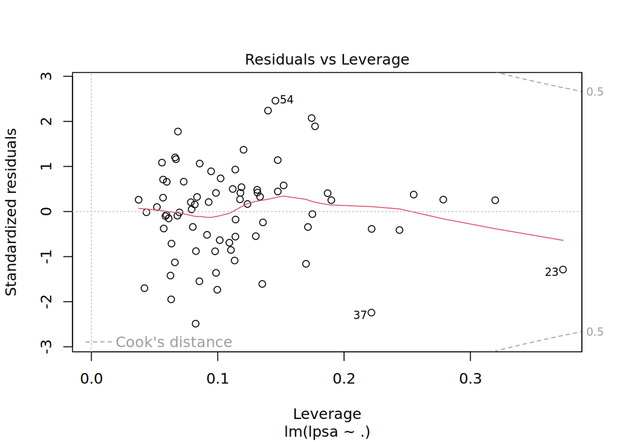

```r
plot(ols_model, which = 5)
```

Most observations have low leverage and moderate residuals. Although a few observations (e.g., 23, 37, and 54) stand out slightly, none appears to have an unusually large influence on the fitted model.

#### Cook’s distance

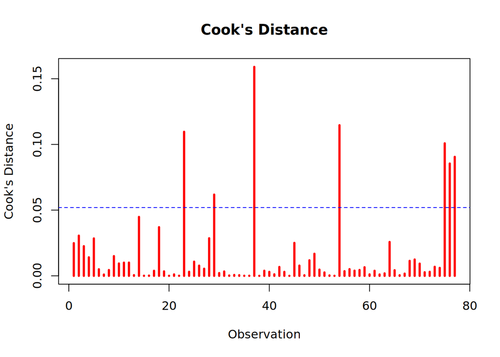

```r
cook <- cooks.distance(ols_model)
plot(
  cook,
  type = "h",
  lwd = 3,
  col = "red",
  xlab = "Observation",
  ylab = "Cook's Distance",
  main = "Cook's Distance"
)
abline(h = 4 / nrow(train_df), col = "blue", lty = 2)
```

Several observations exceed the reference line $4/n$, but all Cook’s distance values are well below 1. Therefore, there is no strong evidence of influential observations.

Taken together, the residual diagnostics do not reveal any serious violation of the standard assumptions underlying OLS regression.

### Ill-conditioned design

```r
vif_manual(ols_model)
```

```
##   lcavol  lweight      age     lbph      svi      lcp  gleason    pgg45
## 2.424950 1.443336 1.334263 1.426827 2.112764 3.239217 2.684981 2.965827
```

The VIF values were computed to assess multicollinearity among the predictors . They range from **1.33** to **3.24**, with the largest values observed for

- `lcp` (3.24),
- `pgg45` (2.97),
- `gleason` (2.68),
- `lcavol` (2.42).

None of the predictors exceeds the commonly used threshold of **5**, indicating that severe multicollinearity is not present in the training design matrix.

This finding is consistent with the correlation analysis in Section 1C. Although several predictor pairs, such as `gleason`–`pgg45` and `lcavol`–`lcp`, exhibit moderate pairwise correlations, it alone does not necessarily imply problematic multicollinearity. VIF measures how well each predictor can be explained by **all remaining predictors simultaneously**, making it a more appropriate diagnostic for coefficient instability.

Overall, the VIF results suggest that the correlations among predictors are not sufficiently strong to produce substantial inflation of the coefficient variances. Therefore, no clear evidence of an ill-conditioned design was found, and the OLS provide an appropriate baseline for comparison with Ridge and Lasso regression in the following sections.

## 2B. Ridge

### Fitting Ridge

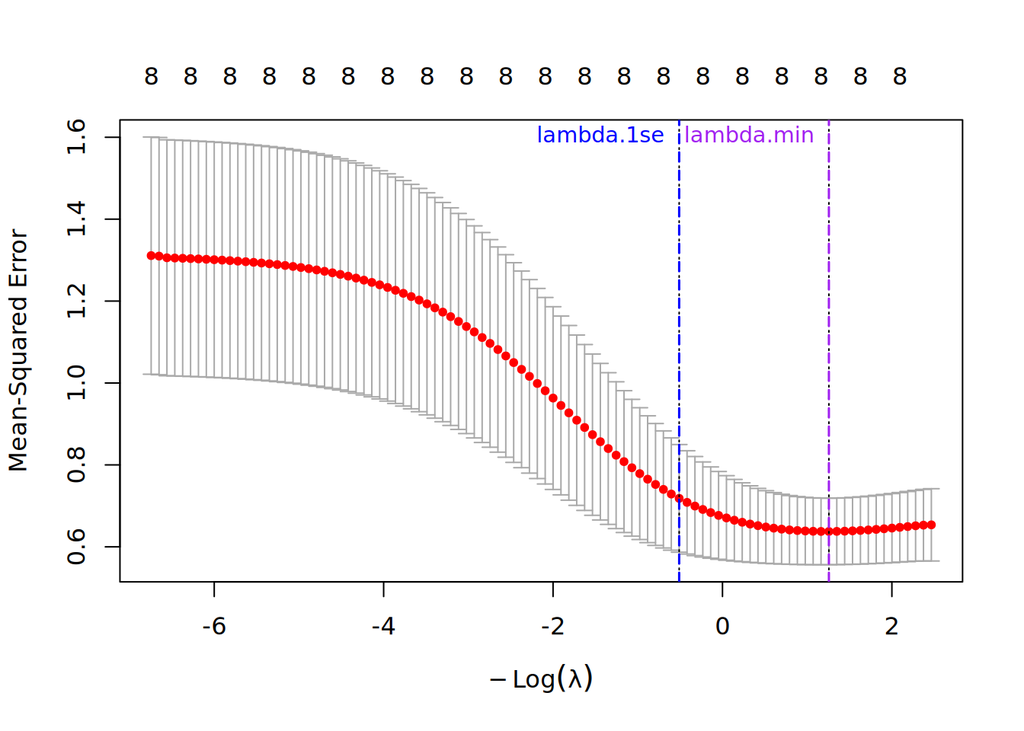

```r
ridge_model <- fit_cv_glmnet(x_train, y_train, alpha = 0, foldid = foldid)

plot(ridge_model)
abline(v = -log(ridge_model$lambda.min), col = "purple", lty = 2, lwd = 1.5)
abline(v = -log(ridge_model$lambda.1se), col = "blue", lty = 2, lwd = 1.5)

y_pos <- max(ridge_model$cvup)
text(-log(ridge_model$lambda.min), y_pos, "lambda.min",
  pos = 2, col = "purple", cex = 0.9
)
text(-log(ridge_model$lambda.1se), y_pos, "lambda.1se",
  pos = 2, col = "blue", cex = 0.9
)
```

The cross-validation curve shows how the prediction error changes with the penalty parameter. The mean cross-validation error decreases until reaching its minimum at **`lambda.min`**. Around the minimum, the error changes only slightly, indicating that a range of penalty values provides similar predictive performance.

Because Ridge regression uses an L2 penalty, every coefficient is continuously shrunk toward zero as the penalty increases. However, Ridge does not apply coordinate-wise thresholding, so no coefficient is set exactly to zero.

### Investigation on `lambda.min` and `lambda.1se`

`lambda.min` is the value of $\lambda$ that minimizes the mean cross-validation error. It is selected when predictive accuracy is the primary objective.

```r
cat(sprintf("lambda.min: %.5f\n", ridge_model$lambda.min))
```

```
## lambda.min: 0.28468
```

```r
min_id <- which(ridge_model$lambda == ridge_model$lambda.min)
cat(sprintf("cvm.min: %.5f\n", ridge_model$cvm[min_id]))
```

```
## cvm.min: 0.63753
```

```r
coef(ridge_model, s = "lambda.min")
```

```
## 9 x 1 sparse Matrix of class "dgCMatrix"
##              lambda.min
## (Intercept)  2.54491818
## lcavol       0.45872792
## lweight      0.17492397
## age         -0.11231149
## lbph         0.10203528
## svi          0.23691430
## lcp          0.08238970
## gleason      0.02447306
## pgg45        0.10953781
```

The coefficients are moderately shrunk compared with the OLS estimates, while the most important predictors still retain relatively large coefficients.

`lambda.1se` is the largest value of $\lambda$ whose cross-validation error is within one standard error of the minimum. It applies stronger regularization, producing a simpler and more stable model while usually maintaining similar predictive performance.

```r
cat(sprintf("lambda.1se: %.5f\n", ridge_model$lambda.1se))
```

```
## lambda.1se: 1.66740
```

```r
se1_id <- which(ridge_model$lambda == ridge_model$lambda.1se)
cat(sprintf("cvm.1se: %.5f\n", ridge_model$cvm[se1_id]))
```

```
## cvm.1se: 0.71834
```

```r
coef(ridge_model, s = "lambda.1se")
```

```
## 9 x 1 sparse Matrix of class "dgCMatrix"
##              lambda.1se
## (Intercept)  2.54491818
## lcavol       0.23622160
## lweight      0.10299748
## age         -0.02250727
## lbph         0.05203722
## svi          0.15871610
## lcp          0.12657524
## gleason      0.04952838
## pgg45        0.08822978
```

Using the larger penalty `lambda.1se` shrinks every coefficient further toward zero than `lambda.min`. The cross-validation error increases only slightly, indicating that a more regularized model can achieve nearly the same predictive performance.

Unlike Lasso, Ridge regression continuously shrinks the coefficients but does not set any coefficient exactly to zero. Therefore, every predictor remains in the fitted model under both tuning parameter choices.

### Coefficient paths

The coefficient paths show how the Ridge coefficients change as the penalty varies.

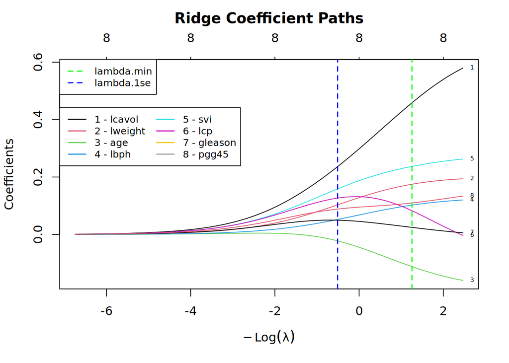

```r
plot(ridge_model$glmnet.fit, xvar = "lambda", label = TRUE)
title("Ridge Coefficient Paths", line = 2.5)

abline(v = -log(ridge_model$lambda.min), col = "green", lty = 2, lwd = 1.5)
abline(v = -log(ridge_model$lambda.1se), col = "blue", lty = 2, lwd = 1.5)

legend("topleft",
  legend = c("lambda.min", "lambda.1se"),
  col = c("green", "blue"),
  lty = 2,
  lwd = 1.5,
  cex = 0.8,
  bg = "white"
)
predictor_names <- rownames(ridge_model$glmnet.fit$beta)
legend("topleft",
  inset = c(0, 0.21),
  legend = paste(1:length(predictor_names), predictor_names, sep = " - "),
  col = 1:length(predictor_names),
  lty = 1,
  lwd = 1.5,
  cex = 0.8,
  bg = "white",
  ncol = 2
)
```

As the penalty decreases (left to right), the coefficients move smoothly away from near zero toward their OLS estimates. Larger penalties produce stronger shrinkage, whereas smaller penalties allow the coefficients to approach the unregularized solution.

### General behavior of correlated predictors

Ridge regression is particularly effective when predictors are highly correlated. In OLS, correlated predictors compete to explain the same variation in the response, leading to unstable coefficient estimates with high variance.

Ridge addresses this issue by shrinking the coefficients of correlated predictors towards each other rather than allowing one predictor to dominate the others. This reduces the variability of the coefficient estimates and improves model stability while retaining all predictors in the model. This behaviour is reflected in the coefficient paths, where all coefficients are smoothly shrunk towards zero as the penalty increases.

#### Examples from the data

The effect of Ridge can be seen in several pairs of highly correlated predictors.

## 2C. Lasso

### Fitting Lasso

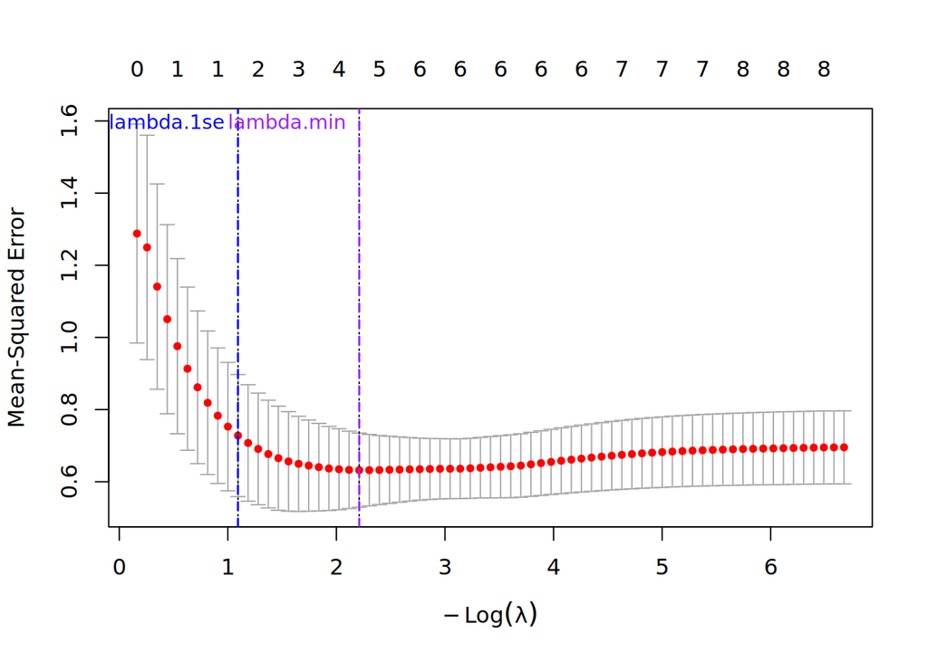

```r
lasso_model <- fit_cv_glmnet(x_train, y_train, alpha = 1, foldid = foldid)

plot(lasso_model)
abline(v = -log(lasso_model$lambda.min), col = "purple", lty = 2, lwd = 1.5)
abline(v = -log(lasso_model$lambda.1se), col = "blue", lty = 2, lwd = 1.5)

y_pos <- max(lasso_model$cvup)
text(-log(lasso_model$lambda.min), y_pos,
  labels = "lambda.min",
  pos = 2, col = "purple", cex = 0.9
)

text(-log(lasso_model$lambda.1se), y_pos,
  labels = "lambda.1se",
  pos = 2, col = "blue", cex = 0.9
)
```

Unlike Ridge, Lasso performs both coefficient shrinkage and variable selection. As the penalty increases, some coefficients are shrunk to zero, producing a simpler and more interpretable model. The cross-validation curve identifies the penalty giving the lowest prediction error (`lambda.min`) together with the largest penalty within one standard error (`lambda.1se`).

### Investigation on `lambda.min` and `lambda.1se`

The optimal penalties and corresponding training cross-validation errors are

```r
cat(sprintf("lambda.min: %.5f\n", lasso_model$lambda.min))
```

```
## lambda.min: 0.10970
```

```r
min_id <- which(lasso_model$lambda == lasso_model$lambda.min)
cat(sprintf("cvm.min : %.5f\n", lasso_model$cvm[min_id]))
```

```
## cvm.min : 0.63210
```

```r
cat(sprintf("lambda.1se: %.5f\n", lasso_model$lambda.1se))
```

```
## lambda.1se: 0.33502
```

```r
se1_id <- which(lasso_model$lambda == lasso_model$lambda.1se)
cat(sprintf("cvm.1se : %.5f\n", lasso_model$cvm[se1_id]))
```

```
## cvm.1se : 0.72788
```

The selected predictors under the two tuning rules are

```r
cat("--- Nonzero coefficients (lambda.min) ---\n")
```

```
## --- Nonzero coefficients (lambda.min) ---
```

```r
coef_min <- coef(lasso_model, s = "lambda.min")
print(coef_min[coef_min[, 1] != 0, ])
```

```
## (Intercept)      lcavol     lweight         svi       pgg45
##  2.54491818  0.60702254  0.10812626  0.17708356  0.02150988
```

```r
cat("\n--- Nonzero coefficients (lambda.1se) ---\n")
```

```
##
## --- Nonzero coefficients (lambda.1se) ---
```

```r
coef_1se <- coef(lasso_model, s = "lambda.1se")
print(coef_1se[coef_1se[, 1] != 0, ])
```

```
## (Intercept)      lcavol         svi
##  2.54491818  0.49176838  0.03845547
```

`lambda.min` prioritizes predictive accuracy and therefore usually keeps more predictors. `lambda.1se` accepts a small increase in prediction error in exchange for a sparser and easier-to-interpret model.

### Coefficient paths

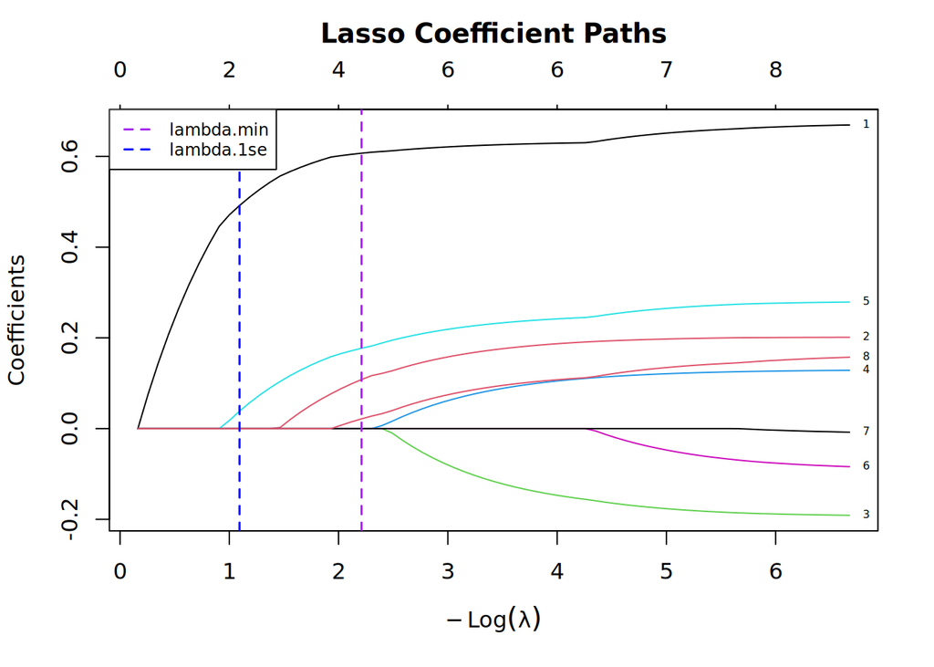

```r
plot(lasso_model$glmnet.fit, xvar = "lambda", label = TRUE)
title("Lasso Coefficient Paths", line = 2.5)

abline(v = -log(lasso_model$lambda.min), col = "purple", lty = 2, lwd = 1.5)
abline(v = -log(lasso_model$lambda.1se), col = "blue", lty = 2, lwd = 1.5)

legend("topleft",
  legend = c("lambda.min", "lambda.1se"),
  col = c("purple", "blue"),
  lty = 2,
  lwd = 1.5,
  cex = 0.75,
  bg = "white"
)
```

Unlike Ridge, Lasso coefficient paths frequently terminate at zero. Variables that reach zero are removed from the model, while only the strongest predictors remain active under larger penalty values.

### Application-specific interpretation

Lasso identifies the predictors that provide the strongest independent contribution to explaining `lpsa` after accounting for the remaining variables.

At `lambda.min`, four predictors remain active: `lcavol`, `lweight`, `svi`, and `pgg45`. Among these, `lcavol` has by far the largest coefficient (0.607), indicating that tumor volume is the strongest predictor of prostate-specific antigen levels. `svi` also remains, suggesting that seminal vesicle invasion contributes additional predictive information beyond tumor volume. `lweight` and `pgg45` have smaller coefficients but still improve predictive performance enough to be retained.

At `lambda.1se`, the stronger penalty removes both `lweight` and `pgg45`, leaving only `lcavol` and `svi`. This indicates that these two variables contain the most robust independent signal in the data. The cross-validation error increases only slightly (0.632 to 0.728), while the model is reduced from four predictors to two, yielding a much simpler and more interpretable model.

The variables excluded by Lasso are not necessarily unrelated to prostate cancer. Rather, after accounting for `lcavol` and `svi`, their remaining predictive contribution is too small to justify the additional model complexity. Some of their information is likely shared with the retained predictors because several clinical measurements are moderately correlated.

## 2D. Training-based comparison and locked core model

This section compares candidate models using only the training data and cross-validation results. The holdout test set is not used.

### Training-based comparison

```r
# OLS
cv_ols <- mean(cv_mse)
l2_ols <- get_l2_norm(ols_model)
l1_ols <- get_l1_norm(ols_model)
nz_ols <- count_nonzero(ols_model)

# Ridge
id_min <- which(ridge_model$lambda == ridge_model$lambda.min)
id_1se <- which(ridge_model$lambda == ridge_model$lambda.1se)

cv_ridge_min <- ridge_model$cvm[id_min]
cv_ridge_1se <- ridge_model$cvm[id_1se]

l2_ridge_min <- get_l2_norm(ridge_model, s = "lambda.min")
l2_ridge_1se <- get_l2_norm(ridge_model, s = "lambda.1se")
l1_ridge_min <- get_l1_norm(ridge_model, s = "lambda.min")
l1_ridge_1se <- get_l1_norm(ridge_model, s = "lambda.1se")

nz_ridge_min <- count_nonzero(ridge_model, s = "lambda.min")
nz_ridge_1se <- count_nonzero(ridge_model, s = "lambda.1se")

# Lasso
id_min <- which(lasso_model$lambda == lasso_model$lambda.min)
id_1se <- which(lasso_model$lambda == lasso_model$lambda.1se)

cv_lasso_min <- lasso_model$cvm[id_min]
cv_lasso_1se <- lasso_model$cvm[id_1se]

l2_lasso_min <- get_l2_norm(lasso_model, s = "lambda.min")
l2_lasso_1se <- get_l2_norm(lasso_model, s = "lambda.1se")
l1_lasso_min <- get_l1_norm(lasso_model, s = "lambda.min")
l1_lasso_1se <- get_l1_norm(lasso_model, s = "lambda.1se")

nz_lasso_min <- count_nonzero(lasso_model, s = "lambda.min")
nz_lasso_1se <- count_nonzero(lasso_model, s = "lambda.1se")

comparison_table <- data.frame(
  Model = c("OLS", "Ridge", "Ridge", "Lasso", "Lasso"),
  Tuning = c("None", "lambda.min", "lambda.1se", "lambda.min", "lambda.1se"),
  CV_MSE = c(cv_ols, cv_ridge_min, cv_ridge_1se, cv_lasso_min, cv_lasso_1se),
  L2_Norm = c(l2_ols, l2_ridge_min, l2_ridge_1se, l2_lasso_min, l2_lasso_1se),
  L1_Norm = c(l1_ols, l1_ridge_min, l1_ridge_1se, l1_lasso_min, l1_lasso_1se),
  Nonzero_Slopes = c(nz_ols, nz_ridge_min, nz_ridge_1se, nz_lasso_min, nz_lasso_1se)
)

knitr::kable(comparison_table, digits = 4)
```

| Model | Tuning | CV_MSE | L2_Norm | L1_Norm | Nonzero_Slopes |
| --- | --- | --- | --- | --- | --- |
| OLS | None | 0.6947 | 0.8154 | 1.7517 | 8 |
| Ridge | lambda.min | 0.6375 | 0.5827 | 1.3013 | 8 |
| Ridge | lambda.1se | 0.7183 | 0.3480 | 0.8368 | 8 |
| Lasso | lambda.min | 0.6321 | 0.6419 | 0.9137 | 4 |
| Lasso | lambda.1se | 0.7279 | 0.4933 | 0.5302 | 2 |

Regularization improves predictive performance over OLS, with both Ridge (`lambda.min`) and Lasso (`lambda.min`) achieving lower cross-validation errors. Ridge shrinks the coefficients but retains all eight predictors, whereas Lasso also performs variable selection. Lasso (`lambda.min`) achieves the lowest cross-validation error while retaining only four predictors, providing the best balance between prediction accuracy and model simplicity.

Note on coefficient norms: Both the $L_2$ and $L_1$ norms of the coefficient vectors (excluding the intercept) are reported. While Ridge explicitly penalizes the $L_2$ norm and Lasso penalizes the $L_1$ norm, tracking both metrics across all models provides a complete picture of how each regularization method shrinks the overall coefficient magnitude versus enforcing sparsity.

### Core model nominated before holdout evaluation

Based on the training results, **Lasso with `lambda.min`** is selected as the core candidate. It achieves the lowest cross-validation error while reducing the model from eight predictors to four. Although Ridge has similar predictive performance, it retains all predictors and is therefore less interpretable.

### Why those lambdas answer different decision questions

`lambda.min` prioritizes predictive performance by minimizing the cross-validation error. In contrast, `lambda.1se` selects a larger penalty to obtain a simpler and more stable model while accepting a small increase in prediction error.

Predictive performance is assessed by the cross-validation error, whereas interpretability depends on model simplicity. In this analysis, Lasso (`lambda.min`) achieves the lowest prediction error while retaining only four predictors, making it the preferred model before the final holdout evaluation.

## 2E. Perturbation or stability check

This investigates how Ridge and Lasso respond to severe multicollinearity by duplicating a predictor with a small amount of random noise. The experiment uses only the training data.

### Prediction before running the check

Before running the perturbation, we expect Ridge to distribute the coefficient between the original and duplicated predictors because the Ridge penalty encourages correlated predictors to share their effects. In contrast, Lasso is expected to retain only one of the two predictors while shrinking the other coefficient to zero.

```r
set.seed(seeds$perturbation)

# duplicate a strong predictor with small random noise
target_idx <- 1
target_name <- colnames(x_train)[target_idx]

duplicate_var <- x_train[, target_idx] + rnorm(nrow(x_train), sd = 0.01)
x_train_pert <- cbind(x_train, duplicate_var = duplicate_var)

# refit Ridge and Lasso using the perturbed data
ridge_pert <- fit_cv_glmnet(x_train_pert, y_train, alpha = 0, foldid = foldid)
lasso_pert <- fit_cv_glmnet(x_train_pert, y_train, alpha = 1, foldid = foldid)

ridge_coef <- coef(ridge_pert, s = "lambda.1se")
lasso_coef <- coef(lasso_pert, s = "lambda.1se")

cat("Ridge:\n")
```

```
## Ridge:
```

```r
print(ridge_coef[c(target_name, "duplicate_var"), , drop = FALSE])
```

```
## 2 x 1 sparse Matrix of class "dgCMatrix"
##               lambda.1se
## lcavol         0.1556046
## duplicate_var  0.1563073
```

```r
cat("\nLasso:\n")
```

```
##
## Lasso:
```

```r
print(lasso_coef[c(target_name, "duplicate_var"), , drop = FALSE])
```

```
## 2 x 1 sparse Matrix of class "dgCMatrix"
##               lambda.1se
## lcavol         .
## duplicate_var  0.4914549
```

### Observed result and explanation

The perturbation confirms the expected behaviour of the two regularization methods.

Overall, the perturbation illustrates the different mechanisms of Ridge and Lasso. Ridge stabilizes coefficient estimates by sharing information across correlated predictors, whereas Lasso produces a sparse and more interpretable model by selecting only one predictor from a correlated group.

# Problem 3. Mathematical mechanisms

## 3A. Ridge and conditioning

Let $X \in \mathbb{R}^{n \times p}, y \in \mathbb{R}^n, b \in \mathbb{R}^p$ and define
$$G = \frac{1}{n} X^\top X, \quad
z = \frac{1}{n} X^\top y$$
consequently, $G \in \mathbb{R}^{p \times p}$ and $z \in \mathbb{R}^p$.

From the objective function
$$Q_\lambda(b)
= \frac{1}{2n}\|y - Xb\|_2^2 + \frac{\lambda}{2}\|b\|_2^2$$

We expand Ridge objective function
$$\begin{align}
Q_\lambda (b) &= \frac{1}{2n} \|y - X b\|_2^2 + \frac{\lambda}{2}
\|b\|_2^2, \quad (\lambda > 0) \\
&= \frac{1}{2n} (y - X b)^\top (y - X b) + \frac{\lambda}{2}
b^\top b \\
&= \frac{1}{2n} (y^\top y - y^\top X b - b^\top X^\top y + b^\top
X^\top X b) + \frac{\lambda}{2} b^\top b \\
&= \frac{1}{2n} (y^\top y - 2 y^\top X b + b^\top X^\top X b) +
\frac{\lambda}{2} b^\top b \\
\end{align}$$

We take the gradient with respect to $b$ and substitute
$$\begin{align}
\nabla_b Q_\lambda (b) &= 0 - \frac{1}{n} X^\top y + \frac{1}{n}
X^\top X b + \lambda b \\
&= - z + G b + \lambda b
\end{align}$$

Set $\nabla_b Q_\lambda (b) = 0 \Leftrightarrow (G + \lambda I_p) b = z$ which is the $\textbf{normal equation}$.

Because $G = \frac{1}{n}X^\top X$ is a positive semi-definite Gram matrix, all its eigenvalues are $\ge 0$. Adding a penalty $\lambda > 0$ along the diagonal (i.e., $\lambda I_p$) shifts all eigenvalues up by $\lambda$. Thus, the matrix $(G + \lambda I_p)$ is strictly positive definite, making it full rank and invertible. This guarantees a unique minimizer

$$\hat{b}_\lambda^{\text{ridge}} = (G +
\lambda I_p)^{-1} z$$

```r
condition_numbers <- safe_condition_numbers(x_train, ridge_model$lambda.min)
kappa_G <- condition_numbers["gram"]
kappa_ridge <- condition_numbers["ridge"]

cat("Condition number of G:", kappa_G, "\n")
```

```
## Condition number of G: 16.96574
```

```r
cat("Condition number of Ridge:", kappa_ridge, "\n")
```

```
## Condition number of Ridge: 7.488802
```

### Numerical interpretation

The OLS estimator is $\hat b=(X^\top X)^{-1}X^\top y$ so its numerical stability depends on the Gram matrix $G= \frac{1}{n} X^\top X$.

When predictors are highly correlated, the columns of $X$ become nearly linearly dependent, making $\det(G)\approx 0$. Equivalently,

$$G=Q\Lambda Q^\top,
\qquad
\Lambda=\operatorname{diag}(\mu_1,\ldots,\mu_p)$$

contains one or more very small eigenvalues. Since

$$G^{-1}
=
Q\Lambda^{-1}Q^\top,
\qquad
\Lambda^{-1}
=
\operatorname{diag}
\left(
\frac1{\mu_1},
\ldots,
\frac1{\mu_p}
\right)$$

A small eigenvalue $\mu_{\min}\approx 0$ produces a very large reciprocal $\frac{1}{\mu_{\min}} \rightarrow \infty$. Therefore, the inverse $(X^\top X)^{-1}$ amplifies small perturbations in the data, making the coefficient estimate $\hat b$ highly sensitive to sampling variation and numerical error. This instability is summarized by the spectral condition number

$$\kappa_2(G)
=
\frac{\mu_{\max}}
{\mu_{\min}}$$

where a large value indicates an ill-conditioned matrix.

Ridge replaces $G$ by $G+\lambda I$ shifts every eigenvalue by $\mu_i \longrightarrow \mu_i+\lambda$. Hence,

$$\kappa_2(G+\lambda I)
=
\frac{\mu_{\max}+\lambda}
{\mu_{\min}+\lambda}$$

Since the smallest eigenvalue increases the most in relative terms, the condition number decreases, making the matrix inversion and coefficient estimates substantially more stable.

### Geometric interpretation

The least-squares objective is

$$RSS(b)=\|y-Xb\|^2$$

whose Hessian is $\nabla^2RSS(b)=2X^\top X=2G$.

Thus, the eigenvalues of $G$ determine the curvature of the loss surface. When one eigenvalue is much smaller than the others, the curvature in that direction is very weak, producing long, narrow elliptical contours. Along this nearly flat valley, many coefficient vectors produce almost identical values of $RSS(b)$, so a small perturbation in the data can move the optimum a large distance, leading to unstable coefficients.

Ridge adds the penalty

$$\lambda\|b\|_2^2$$

whose Hessian is $2\lambda I$. Therefore, the penalized Hessian becomes

$$2(G+\lambda I)$$

increasing the curvature in every direction, especially those corresponding to the smallest eigenvalues. The elongated ellipses become more circular, the optimum is better localized, and the coefficient estimates become more stable while retaining all predictors.

## 3B. Lasso optimality and soft thresholding

Let $X \in \mathbb{R}^{n \times p}, y \in \mathbb{R}^n, b \in \mathbb{R}^p$ and define
$$G = \frac{1}{n} X^\top X = I_p, \quad
z = \frac{1}{n} X^\top y$$
consequently, $G \in \mathbb{R}^{p \times p}$ and $z \in \mathbb{R}^p$.

The objective function
$$R_\lambda (b) =
\frac{1}{2n} \|y - X b\|_2^2 + \lambda \|b\|_1, \quad \|b\|_1 =
\sum_{j=1}^p |b_j|, \lambda > 0$$

We expand Lasso objective function
$$\begin{aligned}
R_\lambda (b) &= \frac{1}{2n} \|y - X b\|_2^2 + \lambda \|b\|_1 \\
&= \frac{1}{2n} (y - X b)^\top (y - X b) + \lambda
\sum_{j=1}^p |b_j| \\
&= \frac{1}{2n} (y^\top y - y^\top X b - b^\top X^\top
y + b^\top X^\top X b) + \lambda \sum_{j=1}^p |b_j|
\end{aligned}$$

The term $y^\top X b$ is is a scalar, therefore $(y^\top X b)^\top = b^\top X^\top (y^\top)^\top = b^\top X^\top y$.

Then the objective becomes
$$\begin{aligned}
R_\lambda (b) &= \frac{1}{2n} y^\top y - \frac{1}{n} b^\top X^\top y
+ \frac{1}{2n} b^\top X^\top X b + \lambda \sum_{j=1}^p |b_j| \\
&= \frac{1}{2n} y^\top y - b^\top z + \frac{1}{2}
b^\top b + \lambda \sum_{j=1}^p |b_j| \\
&= \frac{1}{2n} y^\top y + \sum_{j=1}^p \left( - b_j
z_j + \frac{1}{2} b_j^2 + \lambda |b_j| \right)
\end{aligned}$$

The term $\frac{1}{2n} y^\top y$ is a constant with respect to the variable $b$, leaving a sum of $p$ independent 1-dimensional optimization problems.

Consider a fixed $j$, and let $l_j (t) = \frac{1}{2} t^2 - t z_j + \lambda |t|$, for $t \in \mathbb{R}$. We analyze this in three cases because $|t|$ is *non-differentiable* at $t=0$.

- **Case 1:** If $t > 0$, then $|t| = t$ and $l_j (t) = \frac{1}{2} t^2 - t z_j + \lambda t$. Thus, $l_j' (t) = t - z_j + \lambda$.
  $$l_j' (t) = 0 \iff t
  = z_j - \lambda \quad (1)$$
  Moreover, since we assumed $t > 0$, equation $(1)$ is a valid minimum if and only if $z_j > \lambda$.
- **Case 2:** If $t < 0$, then $|t| = - t$ and $l_j (t) = \frac{1}{2} t^2 - t z_j - \lambda t$. Thus, $l_j' (t) = t - z_j - \lambda$.
  $$l_j' (t) = 0 \iff t
  = z_j + \lambda \quad (2)$$
  Moreover, since we assumed $t < 0$, equation $(2)$ is a valid minimum if and only if $z_j < -\lambda$.
- **Case 3:** If $|z_j| \le \lambda$, there is no valid solution where the derivative equals zero (neither Case 1 nor Case 2). Because the function is strictly convex, the global minimum must exist, which means it is trapped exactly at the non-differentiable corner: $t = 0$. We verify that $t = 0$ minimizes $l_j (t)$ (3).

For any $t \in \mathbb{R}$
$$\begin{aligned}
l_j (t) - l_j (0) &= \frac{1}{2} t^2 - t z_j + \lambda |t| \\
&\ge \frac{1}{2} t^2 - |t| |z_j| + \lambda |t|
\quad (-t z_j \ge -|t| |z_j|) \\
&\ge \frac{1}{2} t^2 - |t| (|z_j| - \lambda) \\
&\ge 0 \quad (|z_j| - \lambda \le 0)
\end{aligned}$$
Therefore, $l_j (t) \ge l_j (0)$ for all $t \in \mathbb{R}$, proving $t=0$ is the global minimum for this range.

Combining these cases yields the soft-thresholding estimator for $\hat{b}_j$:
$$\hat{b}_j = \begin{cases}
z_j - \lambda & \text{if } z_j > \lambda, \\
0 & \text{if } |z_j| \le \lambda, \\
z_j + \lambda & \text{if } z_j < -\lambda
\end{cases}$$

The uniqueness is guaranteed because the objective function is strictly convex. Under the orthogonal design, the variables are perfectly independent, forming a strictly convex “bowl” shape. Even with the sharp point added by the $L_1$ penalty, the strict convexity mathematically ensures there is exactly one absolute global minimum.

**Soft-thresholding operator under orthonormal design** Assume that $\frac{1}{n} X^T X = I_p$. Let $z = \frac{1}{n} X^T y$. Then the Lasso minimizer of $R_\lambda (b)$ is *unique* and has coordinates
$$\hat{b}_j = S_\lambda (z_j),
\quad \text{where the soft-thresholding function is } S_\lambda (z) =
\text{sgn}(z) (|z| - \lambda)_+$$
where $(u)_+ = \max(u, 0)$.

**Why Lasso can produce exact zeros while Ridge generally does not.** Under $\frac{1}{n} X^T X = I_p$, we can compare the closed-form estimators

- **Ridge:** $\hat{b}_j^{\text{Ridge}} = (1 + \lambda)^{-1} z_j$ (proportional shrinkage). It divides the coefficient by a constant. The coefficients get extremely small, but they never become zero. The optimality condition means $b_j$ only equals exactly zero if $z_j$ is exactly zero (which is highly improbable with real data).
- **Lasso:** $\hat{b}_j^{\text{Lasso}} = \text{sgn}(z_j) (|z_j| - \lambda)_+$ (absolute shrinkage). It subtracts a constant from the magnitude. If a coefficient is originally small, the penalty forces it to exactly zero. Case 3 shows that Lasso maps a whole range of values to exactly zero, creating sparsity. This gives Lasso its **feature selection** capability.

## 3C. Connect algebra to evidence

The Ridge results in Section 2B provide direct evidence for the conditioning analysis in Section 3A. At the selected tuning parameter,

$$\lambda_{\min}=0.28468$$

the condition number decreased from $\kappa_2(G)=16.97$ to $\kappa_2(G+\lambda I)=7.49$ representing a reduction of more than 50%. This confirms that adding $\lambda I$ increased the smallest eigenvalues of the Gram matrix, making the linear system substantially better conditioned.

The improved conditioning is reflected in the fitted Ridge coefficients. Compared with OLS, the coefficient of `lcavol` was shrunk from **0.6740** to **0.4587**, while the coefficient of the correlated predictor `lcp` changed from **−0.0924** to **0.0824**. Rather than allowing these correlated predictors to compete for unstable coefficients, Ridge shrinks them simultaneously and distributes their shared contribution more evenly. This behaviour is also visible in the smooth coefficient paths, where all coefficients move continuously towards zero as the penalty increases, but none becomes exactly zero.

Overall, the numerical evidence supports the theoretical result of Section 3A: shifting the eigenvalues by $\lambda$ improves the conditioning of the Gram matrix, leading to more stable coefficient estimates while retaining all predictors.

# Problem 4. Elastic net and a neural-feature bridge

## 4A. Research question and source map

**Research Question.**

How does $L_2$ regularization reduce model complexity in neural networks, and under what conditions is it mathematically equivalent to weight decay during training?

The evidence in the source map answers the research question by showing that integrating an $L_2$ penalty into a neural network’s objective function restricts model capacity by discouraging large parameter values and favoring lower-complexity, minimum-norm solutions (**C5-C7**). This reduces overfitting and generally improves generalization by preventing the model from relying excessively on any individual weight.

The source map also clarifies how this theoretical penalty translates into the algorithmic process of weight decay during optimization. For standard stochastic gradient descent, weight decay is mathematically equivalent to minimizing an objective with an $L_2$ penalty after appropriate learning-rate rescaling (**C1**). However, this equivalence breaks down for adaptive optimizers such as Adam because parameter-specific gradient scaling changes the effective regularization applied to each weight (**C2**). Although an equivalent weighted $L_2$ interpretation exists under a fixed preconditioner (**C3**), practical implementations instead use decoupled weight decay (AdamW), which empirically improves generalization and simplifies hyperparameter tuning (**C4**).

Overall, the literature shows that $L_2$ regularization provides the theoretical mechanism for controlling model complexity, while weight decay is the optimization procedure whose relationship to that penalty depends on the choice of optimization algorithm.

### Source Map

(Loshchilov and Hutter 2019)

(Krogh and Hertz 1991)

| Claim | Exact Source and Locator | What the Source Establishes | What it Does Not Establish |
| --- | --- | --- | --- |
| For SGD, weight decay is equivalent to $L_2$ regularization after learning-rate rescaling. | Loshchilov & Hutter (2019), Section 2, Proposition 1 | Proves the mathematical equivalence between SGD weight decay and $L_2$ regularization. | Does not extend this equivalence to adaptive optimizers. |
| For adaptive optimizers, weight decay is not equivalent to $L_2$ regularization. | Loshchilov & Hutter (2019), Section 2, Proposition 2 | Proves adaptive gradient scaling changes the effect of $L_2$ regularization, motivating AdamW. | Does not prove AdamW always performs better. |
| With a fixed preconditioner, weight decay corresponds to a weighted $L_2$ regularizer. | Loshchilov & Hutter (2019), Section 2, Proposition 3 | Derives the equivalent weighted regularizer under fixed preconditioning. | Does not apply directly to practical Adam with a changing preconditioner. |
| AdamW improves generalization and simplifies hyperparameter tuning. | Loshchilov & Hutter (2019), Sections 4.2–4.4, Figures 2–4 | Shows AdamW achieves lower test error and easier hyperparameter tuning than Adam. | Does not guarantee improvements across all models or datasets. |
| Weight decay selects the minimum-norm solution, improving generalization in linear networks. | Krogh & Hertz (1991), Section 3, Eqs. 6–10 | Proves weight decay removes irrelevant weight components and favors the minimum-norm solution. | Does not prove the result for general non-linear networks. |
| Weight decay reduces overfitting to noisy targets. | Krogh & Hertz (1991), Section 4, Eqs. 12–17 | Derives an optimal weight decay for noisy linear models and shows reduced generalization error. | Does not show the same optimum applies to deep neural networks. |
| Weight decay can be extended to non-linear networks via local linearization. | Krogh & Hertz (1991), Section 5 | Argues that weight decay favors lower-complexity solutions in non-linear networks. | Does not provide a rigorous proof for arbitrary non-linear networks. |
| Weight decay lowers generalization and prediction error on NetTalk. | Krogh & Hertz (1991), Section 6 | Demonstrates improved performance with weight decay on the NetTalk benchmark. | Does not establish the same gains for modern architectures such as CNNs or Transformers. |

## 4B. Elastic net on original predictors

Elastic Net combines the $L_1$ penalty of Lasso and the $L_2$ penalty of Ridge. The objective is to determine whether a mixture of the two penalties can achieve a better balance than either method alone.

```r
alpha_grid <- c(0.10, 0.25, 0.50, 0.75, 0.90)
enet_models <- vector("list", length(alpha_grid))

enet_summary <- data.frame(
  alpha = alpha_grid,
  lambda.min = NA_real_,
  lambda.1se = NA_real_,
  cvm.min = NA_real_,
  cvm.1se = NA_real_,
  nonzero.min = NA_integer_,
  nonzero.1se = NA_integer_
)

for (i in seq_along(alpha_grid)) {
  fit <- fit_cv_glmnet(
    x = x_train, y = y_train,
    alpha = alpha_grid[i], foldid = foldid
  )
  enet_models[[i]] <- fit

  enet_summary$lambda.min[i] <- fit$lambda.min
  enet_summary$lambda.1se[i] <- fit$lambda.1se
  enet_summary$cvm.min[i] <- fit$cvm[which(fit$lambda == fit$lambda.min)]
  enet_summary$cvm.1se[i] <- fit$cvm[which(fit$lambda == fit$lambda.1se)]
  enet_summary$nonzero.min[i] <- count_nonzero(fit, s = "lambda.min")
  enet_summary$nonzero.1se[i] <- count_nonzero(fit, s = "lambda.1se")
}
knitr::kable(enet_summary, digits = 4)
```

| alpha | lambda.min | lambda.1se | cvm.min | cvm.1se | nonzero.min | nonzero.1se |
| --- | --- | --- | --- | --- | --- | --- |
| 0.10 | 0.2056 | 0.9996 | 0.6363 | 0.7127 | 7 | 7 |
| 0.25 | 0.1309 | 0.6366 | 0.6346 | 0.7034 | 7 | 5 |
| 0.50 | 0.1144 | 0.4208 | 0.6335 | 0.7026 | 6 | 5 |
| 0.75 | 0.1106 | 0.3709 | 0.6331 | 0.7159 | 6 | 2 |
| 0.90 | 0.1111 | 0.3392 | 0.6323 | 0.7171 | 4 | 2 |

```r
best_id <- which.min(enet_summary$cvm.min)
best_alpha <- enet_summary$alpha[best_id]
best_model <- enet_models[[best_id]]

cat("Selected alpha :", best_alpha, "\n")
```

```
## Selected alpha : 0.9
```

```r
cat("Selected lambda:", best_model$lambda.min, "\n")
```

```
## Selected lambda: 0.1110642
```

```r
cat("Minimum CV MSE :", min(best_model$cvm), "\n")
```

```
## Minimum CV MSE : 0.6323101
```

```r
coef(best_model, s = "lambda.min")
```

```
## 9 x 1 sparse Matrix of class "dgCMatrix"
##             lambda.min
## (Intercept) 2.54491818
## lcavol      0.60062327
## lweight     0.11674208
## age         .
## lbph        .
## svi         0.18406394
## lcp         .
## gleason     .
## pgg45       0.03091681
```

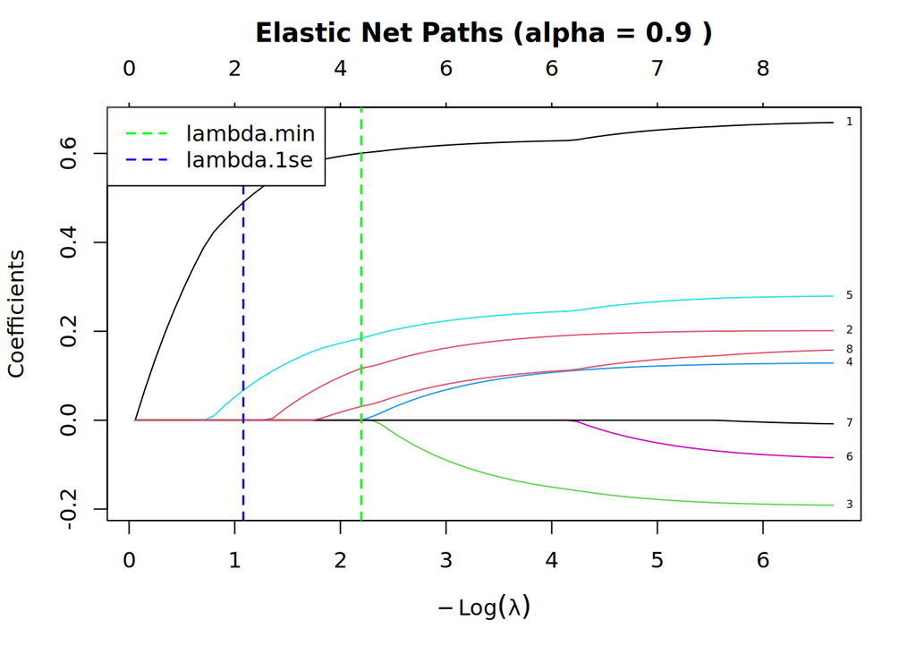

```r
plot(best_model$glmnet.fit, xvar = "lambda", label = TRUE)
title(paste("Elastic Net Paths (alpha =", best_alpha, ")"), line = 2.5)
abline(v = -log(best_model$lambda.min), col = "green", lty = 2, lwd = 1.5)
abline(v = -log(best_model$lambda.1se), col = "blue", lty = 2, lwd = 1.5)
legend("topleft",
  legend = c("lambda.min", "lambda.1se"),
  col = c("green", "blue"), lty = 2, lwd = 1.5, bg = "white"
)
```

### Selection rule

For each candidate value $\alpha$, an Elastic Net model was fitted using the common five-fold cross-validation assignment. For each model, the tuning parameter $\lambda$ was selected by `lambda.min`. The final value of $\alpha$ was then chosen as the one producing the smallest minimum cross-validation error across the candidate grid.

The results are summarized above. As $\alpha$ increases from 0.10 to 0.90, the minimum cross-validation error decreases gradually from **0.6363** to **0.6323**, while the number of active predictors at `lambda.min` decreases from **7** to **4**. Consequently, $\alpha=0.90$ was selected because it achieved the smallest cross-validation error (**CV MSE = 0.6323**) with the sparsest model among the candidate values.

At the selected tuning parameters $\alpha = 0.90, \lambda_{\min}=0.1111$, the fitted model retained four predictors `lcavol`, `lweight`, `svi`, and `pgg45`. The remaining four predictors (`age`, `lbph`, `lcp`, and `gleason`) were shrunk exactly to zero.

### Relationship with Ridge and Lasso in Problem 2

Elastic Net combines the $L_1$ penalty of Lasso with the $L_2$ penalty of Ridge, producing a solution between the two methods.

In Problem 2, Ridge retained all **eight predictors** because the $L_2$ penalty shrinks coefficients continuously without setting them to zero, whereas Lasso shrinks several coefficients exactly to zero.

Thus, the fitted model is much closer to Lasso in terms of variable selection, but the remaining **10%** $L_2$ penalty ($1-\alpha=0.10$) still provides additional coefficient stabilization for correlated predictors. Consequently, Elastic Net combines the sparsity of Lasso with part of the stability and grouping behaviour of Ridge.

## 4C. Fixed ReLU features

Using the standardized training predictors, we constructed $M = 200$ fixed random ReLU features of the form

$$h_m(x)=\max\{a_m^\top x+c_m,0\},
\qquad m=1,\ldots,M$$

where $a_m\sim N\left(0,\frac1pI_p\right)$ and $c_m\sim N(0,0.5^2)$$

The random weights and offsets were generated once using the declared seed and then applied unchanged to both the training and test sets. Hidden features with zero variance in the training data were removed using training information only.

```r
set.seed(seeds$features)

relu <- function(z) pmax(z, 0)
M <- 200L
p <- ncol(x_train)

# generate random hidden-layer parameters
A_matrix <- matrix(rnorm(p * M, mean = 0, sd = sqrt(1 / p)),
  nrow = p, ncol = M
)
c_bias <- rnorm(M, mean = 0, sd = 0.5)

# construct ReLU features
H_train_raw <- relu(sweep(x_train %*% A_matrix, 2, c_bias, "+"))
H_test_raw <- relu(sweep(x_test %*% A_matrix, 2, c_bias, "+"))

# remove constant hidden features using training only
keep_hidden <- apply(H_train_raw, 2, sd) > 0
H_train_raw <- H_train_raw[, keep_hidden, drop = FALSE]
H_test_raw <- H_test_raw[, keep_hidden, drop = FALSE]

cat("Hidden features retained:", ncol(H_train_raw), "out of", M, "\n")
```

```
## Hidden features retained: 198 out of 200
```

```r
# standardize hidden features using training statistics
h_prep <- fit_scaler(H_train_raw)
H_train <- apply_scaler(H_train_raw, h_prep)
H_test <- apply_scaler(H_test_raw, h_prep)
```

Ridge, Lasso, and Elastic Net were fitted on the fixed ReLU feature matrix using the shared five-fold cross-validation assignment. For Elastic Net, the mixing parameter $\alpha$ was selected from the same candidate grid as in Part 4B.

```r
ridge_relu <- fit_cv_glmnet(H_train, y_train, alpha = 0, foldid = foldid)
lasso_relu <- fit_cv_glmnet(H_train, y_train, alpha = 1, foldid = foldid)

alpha_grid <- c(0.10, 0.25, 0.50, 0.75, 0.90)
enet_models <- lapply(
  alpha_grid,
  function(alpha) {
    fit_cv_glmnet(H_train, y_train, alpha = alpha, foldid = foldid)
  }
)

cv_errors <- sapply(enet_models, function(model) min(model$cvm))
best_id <- which.min(cv_errors)
best_alpha_relu <- alpha_grid[best_id]
enet_relu <- enet_models[[best_id]]
```

The selected tuning values, training cross-validation errors, and numbers of active hidden features are summarized below.

```r
relu_summary <- data.frame(
  Model = c("Ridge", "Lasso", "Elastic net"),
  Alpha = c(0, 1, best_alpha_relu),
  Lambda = c(
    ridge_relu$lambda.min,
    lasso_relu$lambda.min,
    enet_relu$lambda.min
  ),
  CV_Error = c(min(ridge_relu$cvm), min(lasso_relu$cvm), min(enet_relu$cvm)),
  Active_Hidden = c(
    count_nonzero(ridge_relu),
    count_nonzero(lasso_relu),
    count_nonzero(enet_relu)
  )
)

knitr::kable(relu_summary,
  digits = 4,
  caption = "Cross-validation results on the fixed ReLU features."
)
```

Cross-validation results on the fixed ReLU features.

| Model | Alpha | Lambda | CV_Error | Active_Hidden |
| --- | --- | --- | --- | --- |
| Ridge | 0.0 | 7.9035 | 0.6980 | 198 |
| Lasso | 1.0 | 0.1414 | 0.7719 | 11 |
| Elastic net | 0.1 | 1.0208 | 0.7323 | 46 |

### Fixed and learned parameters

The hidden-layer weight vectors $a_m$ and offsets $c_m$ were fixed after being generated once from their specified normal distributions. These random feature parameters were reused unchanged for both the training and test sets and were not estimated from the data.

The learned quantities were the regression coefficients associated with the hidden features and the intercept. Cross-validation selected $\lambda$ for Ridge and Lasso, and selected both $\alpha$ and $\lambda$ for Elastic Net.

Among the three models, Ridge achieved the smallest training cross-validation error (0.6980) but retained almost every hidden feature (198), producing the least sparse model. Lasso selected only 11 active hidden features, giving the sparsest representation but also the largest cross-validation error (0.7719). Elastic net selected $\alpha=0.10$, retained 46 hidden features, and achieved an intermediate cross-validation error (0.7323), providing a compromise between prediction accuracy and sparsity.

## 4D. Locked analysis and final holdout evaluation

### Locked analysis declaration

Before inspecting the holdout responses (`y_test`), the analysis was locked as follows.

```r
pred_ols <- predict(ols_model, newdata = as.data.frame(x_test))
pred_ridge <- as.numeric(predict(ridge_model, newx = x_test, s = "lambda.min"))
pred_lasso <- as.numeric(predict(lasso_model, newx = x_test, s = "lambda.min"))
pred_enet <- as.numeric(predict(best_model, newx = x_test, s = "lambda.min"))

pred_ridge_relu <- as.numeric(
  predict(ridge_relu, newx = H_test, s = "lambda.min")
)

pred_lasso_relu <- as.numeric(
  predict(lasso_relu, newx = H_test, s = "lambda.min")
)

pred_enet_relu <- as.numeric(
  predict(enet_relu, newx = H_test, s = "lambda.min")
)

holdout_results <- data.frame(
  Model = c(
    "OLS", "Ridge", "Lasso", "Elastic Net", "Ridge + ReLU",
    "Lasso + ReLU", "Elastic Net + ReLU"
  ),
  RMSE = c(
    score_regression(y_test, pred_ols)["RMSE"],
    score_regression(y_test, pred_ridge)["RMSE"],
    score_regression(y_test, pred_lasso)["RMSE"],
    score_regression(y_test, pred_enet)["RMSE"],
    score_regression(y_test, pred_ridge_relu)["RMSE"],
    score_regression(y_test, pred_lasso_relu)["RMSE"],
    score_regression(y_test, pred_enet_relu)["RMSE"]
  ),
  MAE = c(
    score_regression(y_test, pred_ols)["MAE"],
    score_regression(y_test, pred_ridge)["MAE"],
    score_regression(y_test, pred_lasso)["MAE"],
    score_regression(y_test, pred_enet)["MAE"],
    score_regression(y_test, pred_ridge_relu)["MAE"],
    score_regression(y_test, pred_lasso_relu)["MAE"],
    score_regression(y_test, pred_enet_relu)["MAE"]
  )
)

knitr::kable(holdout_results,
  digits = 4,
  caption = "Holdout performance of all locked candidate models."
)
```

Holdout performance of all locked candidate models.

| Model | RMSE | MAE |
| --- | --- | --- |
| OLS | 0.7296 | 0.6137 |
| Ridge | 0.7654 | 0.6230 |
| Lasso | 0.7743 | 0.6167 |
| Elastic Net | 0.7676 | 0.6137 |
| Ridge + ReLU | 0.7660 | 0.6238 |
| Lasso + ReLU | 0.7787 | 0.6391 |
| Elastic Net + ReLU | 0.7563 | 0.6134 |

### Holdout evaluation

The holdout evaluation was performed only once after the analysis had been locked. No hyperparameters were retuned, no predictors were replaced, and no random features were regenerated after inspecting the holdout responses.

OLS achieved the smallest holdout RMSE (0.7296), while Elastic Net with fixed ReLU features achieved the smallest MAE (0.6134). Among the regularized models, Elastic Net with fixed ReLU features also produced the smallest RMSE (0.7563), improving on Elastic Net fitted to the original predictors (0.7676).

## 4E. Deep-learning connection and limitations

### 1. Ridge penalty versus weight decay

In neural networks, weight decay also encourages smaller weights by shrinking the parameters during optimization. When using standard gradient descent, weight decay is mathematically equivalent to adding an $L_2$ penalty to the loss function because every parameter is updated using the same global learning rate. The shrinkage introduced by weight decay is therefore identical to the shrinkage produced by the gradient of the $L_2$ penalty.

However, this equivalence does not always hold for adaptive optimizers such as Adam. Adam computes an individual adaptive learning rate for each parameter based on the history of its gradients. As a result, the gradient contribution from the $L_2$ penalty is also scaled differently for each weight, so the effective regularization varies across parameters. In contrast, weight decay shrinks each parameter directly, independently of the adaptive gradient scaling. Consequently, adding an $L_2$ penalty to the objective and applying weight decay during optimization are no longer mathematically identical. Optimizers such as AdamW decouple weight decay from the gradient update, restoring the intended behavior of uniform parameter shrinkage.

### 2. Zero output weights versus sparse input-to-hidden weights

Each hidden neuron computes a nonlinear feature from the input, which is then passed to the output layer. The prediction can be written as

$$\hat{y}=\sum_{m=1}^{M} w_m
h_m(x),$$

where $h_m(x)$ is the output of the $m$-th hidden neuron and $w_m$ is its corresponding output weight.

If Lasso shrinks an output weight $w_m$ to zero, the corresponding hidden feature contributes nothing to the prediction and is effectively removed from the scalar predictor.

However, this does **not** create sparse input-to-hidden weights. The parameters defining the hidden feature, namely its input weights and biases, remain unchanged. The hidden neuron still computes the same feature; its output is simply multiplied by zero before reaching the prediction. Therefore, sparsity is created only in the **output-layer weights**, not in the **input-to-hidden connections**.

### 3. Dropout versus permanent pruning

Dropout randomly sets a subset of neuron activations to zero during each training iteration. The neurons that are masked change from one iteration to the next, so every neuron continues to participate in learning over the course of training. This randomness discourages co-adaptation between neurons and generally improves model generalization.

Permanent pruning is fundamentally different. It removes selected weights or neurons permanently so that they no longer participate in either training or prediction. Thus, dropout is a temporary stochastic regularization technique, whereas pruning permanently reduces the model architecture.

### 4. Conclusions cannot be generalized to fully trained deep networks

This experiment uses a **frozen hidden layer**, where the random hidden weights and biases are generated once and remain fixed. Only the output weights are learned. Consequently, the experiment evaluates regularization on **fixed random features** rather than on representations learned jointly with the hidden layers. The results therefore cannot be directly generalized to fully trained deep neural networks, where all layers are optimized together.

### Limitations

1. **Sensitivity to the random-feature seed.** The hidden features are generated from a single random initialization. Different seeds may produce different feature representations and model performance, so the results may depend on the chosen seed.
2. **Frozen hidden representation.** Since only the output layer is trained, the experiment does not evaluate how regularization affects feature learning in end-to-end trained neural networks.
3. **Limited experimental setting.** The conclusions are based on one hidden-layer architecture with 200 ReLU features and a single dataset. They may not generalize to deeper architectures, different activation functions, or other datasets.

# Problem 5. Report quality and reproducibility

## 5A. Reproduction record

To independently reproduce the results in this report, execute the following steps from a clean R session.

### 1. Folder Layout and Setup

Ensure the working directory contains the R Markdown file, the bibliography file, and the raw CSV datasets inside a local `data/` subdirectory:

```
STAT02-Lab-Project/
├── ASESII_24A02_ProjectExam_Ridge_Lasso_ProblemStatement.pdf
├── data/
    └── prostate.csv
├── README.md
└── templates/
    ├── ASESII_24A02_ProjectExam_SampleSubmission.Rmd
    ├── ASESII_24A02_ProjectExam_SampleSubmission.pdf
    ├── Group06_AI_Log.csv
    └── references.bib
```

### 2. Commands execution

Open a clean R session (RStudio via `Session -> Restart R`), clear the workspace, and render the document from the console using relative paths

```r
# clear workspace and verify clean session
rm(list = ls())
gc()

# Render the report to HTML/PDF using relative paths
rmarkdown::render("templates/ASESII_24A02_ProjectExam_SampleSubmission.Rmd", output_format = "all")
```

### 3. Holdout

- **Where holdout responses first enter:** The holdout response vector `y_test` is partitioned during the initial data split in **Section 1B (`split-and-scale`)**, but it is strictly quarantined throughout all exploratory data analysis (Section 1C), baseline OLS modeling (Section 2A), regularized model tuning (Sections 2B–2C), and non-linear feature engineering (Section 4C).
- **First computation:** `y_test` enters mathematical computation for the first and only time in **Section 4D (`final-holdout-evaluation`)**, where it is evaluated against fixed candidate predictions to compute out-of-sample Root Mean Squared Error (RMSE) and Mean Absolute Error (MAE).

## 5B. Recommendation and limitations

### 1. Final deployment recommendation

Although the OLS model achieved the lowest holdout RMSE on this particular train/test split, we recommend the **Elastic Net model** (using the tuning parameters) for practical deployment.

This recommendation reflects the model selection procedure adopted in this study. Hyperparameters were selected exclusively by cross-validation on the training data, while the holdout set was reserved for a single unbiased final evaluation. Because the prostate cancer predictors exhibit moderate multicollinearity, Elastic Net provides a good balance between predictive performance, coefficient stability, and model complexity. Although OLS performed slightly better on this particular holdout split, Elastic Net is expected to provide more robust performance across future samples.

### 2. Prediction versus interpretation

The preferred model depends on the objective of the analysis.

- **Prediction.** For predicting future patient outcomes, the selected Elastic Net model provides a good compromise between predictive accuracy, coefficient stability, and model complexity. Its regression coefficients should be interpreted only as conditional associations within the fitted model and **not as evidence of causal effects**.
- **Interpretation.** If the primary objective is identifying a compact subset of important predictors rather than maximizing predictive accuracy, a more strongly regularized Lasso model may be preferred. This produces a simpler and more interpretable model while accepting a small reduction in predictive performance.

### 3. Study limitations

- **Small sample size.** The analysis is based on only 97 observations (77 training and 20 holdout samples). Consequently, performance estimates are subject to sampling variability, and different data splits may produce different model rankings.
- **Limited external validity.** The dataset represents a historical clinical cohort from a single institution. External validation on more recent and diverse patient populations would be required before clinical deployment.
- **Single holdout evaluation.** Model performance was evaluated using one fixed holdout partition. Although this preserves an unbiased final assessment, it does not quantify the variability of the reported test errors across repeated train/test splits.
- **Fixed random feature mapping.** The ReLU feature expansion in Section 4 used randomly generated hidden features without backpropagation. Therefore, the results evaluate fixed random feature representations rather than fully trained neural networks.

# Preflight and session information

```r
# audit: verify every critical pipeline object exists before generating
# final deliverables
required_objects <- c("train_id", "test_id", "x_train", "x_test", "y_train",
  "y_test", "foldid", "ols_model", "ridge_model", "lasso_model")

missing_objects <- setdiff(required_objects, ls())
if (length(missing_objects) > 0) {
  stop("Preflight Check Failed. Missing required pipeline objects: ",
    paste(missing_objects, collapse = ", "))
}

# safeguard: verify absolute zero row overlap between train and test partitions
stopifnot("Data Leakage Alert: Train and test indices overlap!" =
  length(intersect(train_id, test_id)) == 0L)
cat(
  "Preflight audit passed: Folds, objects, and leakage boundaries are
  verified.\n")
```

```
## Preflight audit passed: Folds, objects, and leakage boundaries are
##   verified.
```

Krogh, Anders, and John A. Hertz. 1991. “A Simple Weight Decay Can Improve Generalization.” *Advances in Neural Information Processing Systems (NeurIPS)* 4: 950–57.

Loshchilov, Ilya, and Frank Hutter. 2019. “Decoupling Weight Decay from Gradient-Based Optimizers.” *International Conference on Learning Representations (ICLR)*.

Stamey, Thomas A., John N. Kabalin, John E. McNeal, et al. 1989. “Prostate Specific Antigen in the Diagnosis and Treatment of Adenocarcinoma of the Prostate. II. Radical Prostatectomy Treated Patients.” *The Journal of Urology* 141 (5): 1076–83.